# Regression Analysis

```r
# Compute R-squared, adjusted R-squared, RMSE, and AIC for each model
metrics <- data.frame(
  Model = c("Model1", "Model2", "Model3", "Model4", "Model5"),
  R2 = c(summary(model1)$r.squared, summary(model2)$r.squared,
         summary(model3)$r.squared, summary(model4)$r.squared,
         summary(model5)$r.squared),
  Adj_R2 = c(summary(model1)$adj.r.squared, summary(model2)$adj.r.squared,
             summary(model3)$adj.r.squared, summary(model4)$adj.r.squared,
             summary(model5)$adj.r.squared),
  RMSE = c(sqrt(mean(model1$residuals^2)), sqrt(mean(model2$residuals^2)),
           sqrt(mean(model3$residuals^2)), sqrt(mean(model4$residuals^2)),
           sqrt(mean(model5$residuals^2))),
  AIC = c(AIC(model1), AIC(model2), AIC(model3), AIC(model4), AIC(model5))
)

# Print the metrics table
print(metrics)
```

```
##    Model        R2    Adj_R2      RMSE      AIC
## 1 Model1 0.8158701 0.7804605  5.513495 214.0728
## 2 Model2 0.8083186 0.7799213  5.625419 213.3590
## 3 Model3 0.6479352 0.5957775  7.623882 232.8143
## 4 Model4 0.4768116 0.4207557  9.293813 243.4904
## 5 Model5 0.2970607 0.2736293 10.772681 248.9409
```

Conclusion : As R^2 and Adjusted R^2 is considered to be the confidence of the model and the Robustness to overfit respectively, A high R^2 and Adjusted R^2 indicates that it explains a greater proportion of the variance in the dependent variable while considering the number of predictors.So we we can consider Model_1 as the best model as it has highest R^2 and Adjusted R^2 value and comparatively less AIC and RMSE value.

#### 6. For the best model, due the residual analysis to verify if the model best fits the data with analysis.

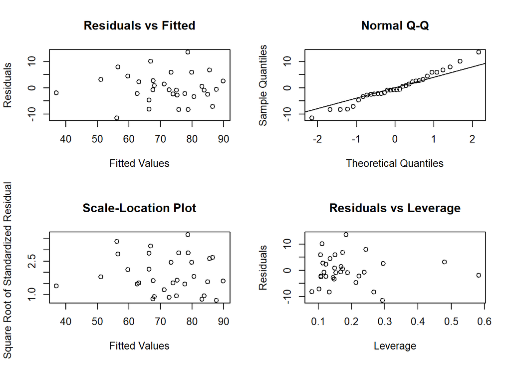

```r
# Select the best model based on the metrics
best_model <- model1

# Obtain the residuals
residuals <- resid(best_model)

# Plot the diagnostic plots
par(mfrow = c(2, 2))

# Residuals vs Fitted values plot
plot(fitted(best_model), residuals,
     xlab = "Fitted Values",
     ylab = "Residuals",
     main = "Residuals vs Fitted")

# Normal Q-Q plot
qqnorm(residuals, main = "Normal Q-Q")
qqline(residuals)

# Scale-Location plot (Square root of standardized residuals vs Fitted values)
plot(fitted(best_model), sqrt(abs(residuals)),
     xlab = "Fitted Values",
     ylab = "Square Root of Standardized Residuals",
     main = "Scale-Location Plot")

# Residuals vs Leverage plot
plot(hatvalues(best_model), residuals,
     xlab = "Leverage",
     ylab = "Residuals",
     main = "Residuals vs Leverage")
```

plot(fitted(best_model), residuals, …) - creates the residuals vs. fitted values plot, where we examine if the residuals have a random pattern around zero, indicating a good fit.

qqnorm(residuals) and qqline(residuals) - create a normal Q-Q plot, where we check if the residuals follow a straight line, indicating normality.

plot(hatvalues(best_model), residuals, …) creates the residuals vs. leverage plot. This plot helps us identify influential observations with high leverage and assess if any observations are outliers.

Conclusion : 1. From the scatter plot of the Residuals we can see that it is pretty randomly distributed which can be a indication of a good fitted model. 2. Normal Q-Q plot shows that if the error follows a Normal distribution and from the curve it can be seen that the error of the chosen model is normally distributed. 3. Residual Vs Leverage plot helps us to find potential outliers , in this case we can see that there are very few of them . which is a good indication.

#### 7. For the best model selected, construct the 90% confidence interval for each of the parameters. Write the code/function for confidence interval and cross verify your answer with the inbuilt function.

```r
# Selecting the best model based on the metrics
best_model <- model1

# Calculating the 90% confidence intervals using confint()
conf_intervals <- confint(best_model, level = 0.90)

# Printing the confidence intervals
print(conf_intervals)
```

```
##                          5 %        95 %
## (Intercept)      49.09745105 83.39820190
## Agriculture      -0.33979783 -0.07059245
## Examination      -0.73107323  0.17967958
## Education        -1.21028474 -0.58238851
## Catholic          0.06116849  0.17775699
## Infant.Mortality  0.66539128  1.95523861
```

```r
# Manually calculating the confidence intervals
n <- nrow(train_data)  # Number of observations
p <- length(coefficients(best_model))  # Number of parameters (including intercept)
t_value <- qt((1 - 0.90) / 2, df = n - p)  # T-distribution critical value
se <- sqrt(diag(vcov(best_model)))  # Standard errors of the parameters
coefficients(best_model) + t_value * se  # Upper confidence bounds
```

```
##      (Intercept)      Agriculture      Examination        Education
##      49.09745105      -0.33979783      -0.73107323      -1.21028474
##         Catholic Infant.Mortality
##       0.06116849       0.66539128
```

```r
coefficients(best_model) - t_value * se  # Lower confidence bounds
```

```
##      (Intercept)      Agriculture      Examination        Education
##      83.39820190      -0.07059245       0.17967958      -0.58238851
##         Catholic Infant.Mortality
##       0.17775699       1.95523861
```

#### 8. Use the best model and its estimated coefficient values to make predictions for Fertility on the test data.

```r
# Select the best model based on the metrics
best_model <- model1

# Obtain the test data
test_data <- swiss[-train_indices, ]

# Make predictions on the test data
predictions <- predict(best_model, newdata = test_data)

# Print the predictions
print(predictions)
```

```
##   Courtelary     Delemont   Porrentruy    Echallens     Lausanne       Lavaux
##     78.14686     86.49653     95.92293     75.26512     57.91655     64.50889
##       Moudon        Nyone         Orbe      Yverdon    Entremont   St Maurice
##     78.28384     62.67295     64.80438     74.99533     79.37114     75.28280
## La Chauxdfnd   Val de Ruz  Rive Gauche
##     75.32176     74.92271     60.76217
```

#### 9. Compute RMSE, MAE between the actual values of response (in test data) and the predicted values.

```r
# Select the best model based on the metrics
best_model <- model1

# Obtain the test data
test_data <- swiss[-train_indices, ]

# Make predictions on the test data
predictions <- predict(best_model, newdata = test_data)

# Extract the actual values of the response variable
actual_values <- test_data$Fertility

# Compute RMSE
rmse <- sqrt(mean((actual_values - predictions)^2))

# Compute MAE
mae <- mean(abs(actual_values - predictions))

# Print RMSE and MAE
print(paste("RMSE:", rmse))
```

```
## [1] "RMSE: 9.83958447898174"
```

```r
print(paste("MAE:", mae))
```

```
## [1] "MAE: 8.13446903835993"
```

#### 10. Plot the actual test data values Vs the predicted values. Use different colours for plots and add legend, title and suitable labels.

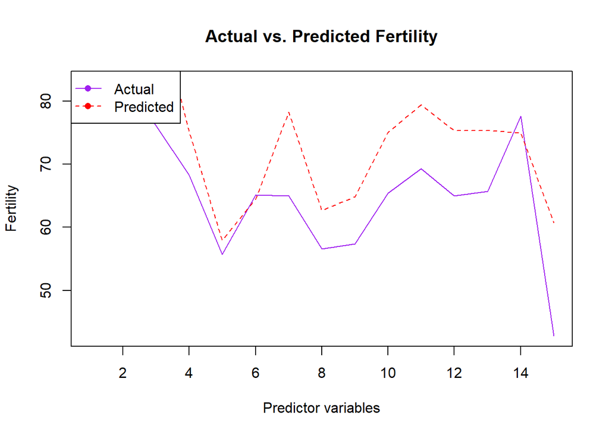

```r
test_data$y_predicted <- predict(model1, newdata = test_data)

x_values <- 1:nrow(test_data)

plot(test_data$Fertility, col = "purple",type="l", pch = 16, xlab = "Predictor variables", ylab = "Fertility",
     main = "Actual vs. Predicted Fertility")
lines(test_data$y_predicted, col = "red", lty = 2)
legend("topleft", legend = c("Actual", "Predicted"), col = c("purple", "red"), lty = c(1, 2), pch = 16)
```